# Module 2- Ames Iowa Dataset- Inferential Analytics: Chi and Anova

Ananya Sharma

21/01/2022

- Installing the Packages
- Read the file from the source
- Introduction to the Ames Iowa Housing dataset
- Quantile Division of Sales Price
- Chi Square Test
- Adding Contingency Table in R
- Mosiac Plot to see the distribution of categorical data
- Boxplot to check Homoscedasticity between Sale Price & Neighborhood.
- Contingency Table
- Two-Way Anova Test
- Interaction Plot
- Analysis & Conclusion
- References:-

## Installing the Packages

- Combining all the packages, using pacman library and p_load function, in order to call all the files.

```r
#install.packages("ggplot2")
#install.packages("tidyr")
#install.packages("ggstatsplot")
#install.packages("dplyr")
#install.packages("purrr")
#install.packages("magrittr")
#install.packages("pacman")
#install.packages("rmarkdown")   # for running  table of contents
#install.packages("yaml")
#install.packages("knitr")


library(pacman)                                       # function to call all the packages at once

p_load(ggplot2, dplyr,quantreg,ggstatsplot,tidyverse,purrr,magrittr,pacman,tidyr,rmarkdown)
```

## Read the file from the source

- Reading the source file into R Markdown Environment.

```r
getwd()
```

```
## [1] "D:/Intermediate Analytics/Module two"
```

```r
Dataset_Ames<-read.csv("AmesHousing.csv")
```

## Introduction to the Ames Iowa Housing dataset

- The Box plot below shows the median between Neighborhood and Sale Price.
- Majority of the homes are priced at $1,70,000.(Median)
- The data shows a lot of outliers as well in sales prices of a few neighborhoods like Crawford,Edwards, etc.
- `The purpose` of this project is to find the chi square test and the the Two Way Anova test results

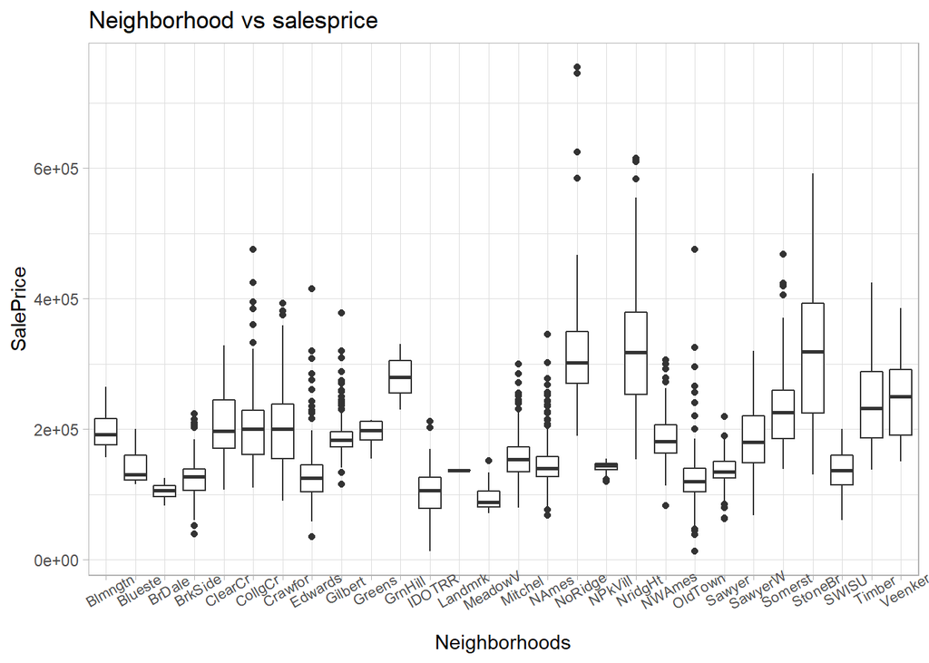

Figure:Neighborhood Vs Saleprice EDA

```r
Dataset_Ames %>% ggplot(aes(factor(Neighborhood), SalePrice),fill=factor(Neighborhood)) + geom_boxplot() + xlab('Neighborhoods') + theme_light() + xlab("Neighborhoods")  + ggtitle("Neighborhood vs salesprice")+ theme(axis.text.x=element_text(size=8, angle=30))
```

## Quantile Division of Sales Price

- We have used the cut function to distribute the Sale Price into five quantiles, namely 20th,40th,60th,80th and 100th percentiles.
- Creating a table that categorizes value according to the percentile of the Sales Prices and the frequency at which the neighborhoods are distributed according to the sales price.
- Several Neighborhoods like LandMrk, GrnHill have very less values and can be clubbed along with other nearest neighborhoods, for a better chi square analysis.
- `Difficulties faced:` It was difficult to look at the map and club the values, since the colors were not demarcated sharply in the map.However, for a chi square test the expected cell count must not be less than five. I faced issues in merging the cells and getting conclusive results
- Clubbing the columns also revealed that there was no significant difference to the value of the chi square p value, hence I did not merge the cells.

```r
Ames<-as.data.frame(Dataset_Ames)

Divisions<-cut(Ames$SalePrice,breaks=quantile(Ames$SalePrice,prob=c(0.0,0.20,0.40,0.60,0.80,1.0)),labels=c("P20","P40","P60","P80","P100"),include.lowest = TRUE)

#Divisions            #call

#typeof(Divisions )          #type integer

Categorized_Ames<-data.frame(Divisions,Ames$Neighborhood)   #Converting to data frame

#Categorized_Ames                  # call

#typeof(Categorized_Ames)      #Find the type of the variable

d<-table(Categorized_Ames) # assigning the table to a variable d
addmargins(d)  # For creating the sum total of all the columns that we created
```

```
         Ames.Neighborhood
Divisions Blmngtn Blueste BrDale BrkSide ClearCr CollgCr Crawfor Edwards
     P20        0       5     28      52       1       9       5      94
     P40        0       1      2      34       4      39      15      55
     P60        8       2      0      13       8      38      20      24
     P80       16       2      0       9      14     120      32      12
     P100       4       0      0       0      17      61      31       9
     Sum       28      10     30     108      44     267     103     194
         Ames.Neighborhood
Divisions Gilbert Greens GrnHill IDOTRR Landmrk MeadowV Mitchel NAmes NoRidge
     P20        1      0       0     65       0      32       9    95       0
     P40        3      0       0     19       1       4      38   177       0
     P60       61      2       0      7       0       1      40   125       0
     P80       84      6       1      2       0       0      17    34       2
     P100      16      0       1      0       0       0      10    12      69
     Sum      165      8       2     93       1      37     114   443      71
         Ames.Neighborhood
Divisions NPkVill NridgHt NWAmes OldTown Sawyer SawyerW Somerst StoneBr SWISU
     P20        2       0      2     133     36      11       0       0    16
     P40       14       0      9      60     67      17       4       1    15
     P60        7       6     49      32     43      30      37       1    13
     P80        0      26     53       8      5      48      58      11     4
     P100       0     134     18       6      0      19      83      38     0
     Sum       23     166    131     239    151     125     182      51    48
         Ames.Neighborhood
Divisions Timber Veenker  Sum
     P20       0       0  596
     P40       1       0  580
     P60      12       3  582
     P80      22       7  593
     P100     37      14  579
     Sum      72      24 2930
```

## Chi Square Test

- When you have two nominal variables and you wish to see if the variation of one variable is  
  different from the other variable, we use the chi-square test of independence.
- The cut function used above ensures that both the variables are categorical.(Meeting one of the assumptions of the Chi square test.)
- `Ho`: The Two variables- Sales Price and Neighborhood are independent.
- `H1`: The two variables- Sales Price and Neighborhood are not independent.

```r
Test_chi<-chisq.test(table(Categorized_Ames))
Test_chi
```

```
    Pearson's Chi-squared test

data:  table(Categorized_Ames)
X-squared = 2723.6, df = 108, p-value < 2.2e-16
```

- P value less than the significance value 0.05 indicates that we can reject the null hypothesis.
- The degree of freedom in the chi square is also it’s mean. So the mean of the distribution is 108.
- `Difficulties Faced`: I tried to run the F test and the Bartlet test to check the variance between the two variables but error cropped up stating that there must be atleast two observations in each group.

## Adding Contingency Table in R

- Contingency tables are not only useful in summarizing data but also for displaying relationships between variables.
- They are a method of combining category variables in one table format for further analysis.

```r
 addmargins(table(Categorized_Ames))
```

```
         Ames.Neighborhood
Divisions Blmngtn Blueste BrDale BrkSide ClearCr CollgCr Crawfor Edwards
     P20        0       5     28      52       1       9       5      94
     P40        0       1      2      34       4      39      15      55
     P60        8       2      0      13       8      38      20      24
     P80       16       2      0       9      14     120      32      12
     P100       4       0      0       0      17      61      31       9
     Sum       28      10     30     108      44     267     103     194
         Ames.Neighborhood
Divisions Gilbert Greens GrnHill IDOTRR Landmrk MeadowV Mitchel NAmes NoRidge
     P20        1      0       0     65       0      32       9    95       0
     P40        3      0       0     19       1       4      38   177       0
     P60       61      2       0      7       0       1      40   125       0
     P80       84      6       1      2       0       0      17    34       2
     P100      16      0       1      0       0       0      10    12      69
     Sum      165      8       2     93       1      37     114   443      71
         Ames.Neighborhood
Divisions NPkVill NridgHt NWAmes OldTown Sawyer SawyerW Somerst StoneBr SWISU
     P20        2       0      2     133     36      11       0       0    16
     P40       14       0      9      60     67      17       4       1    15
     P60        7       6     49      32     43      30      37       1    13
     P80        0      26     53       8      5      48      58      11     4
     P100       0     134     18       6      0      19      83      38     0
     Sum       23     166    131     239    151     125     182      51    48
         Ames.Neighborhood
Divisions Timber Veenker  Sum
     P20       0       0  596
     P40       1       0  580
     P60      12       3  582
     P80      22       7  593
     P100     37      14  579
     Sum      72      24 2930
```

## Mosiac Plot to see the distribution of categorical data

- This plot is done two show the relation between two categorical variables.
- In R Programming, the Mosaic Plot is highly useful for displaying information from a contingency table.
- The relative value is represented by the height of the rectangle drawn by the R Mosaic Plots.
- `Difficulties Faced`: The x label of the map is not very clear. Henceforth, I have not been able to draw conclusive results from the plot.

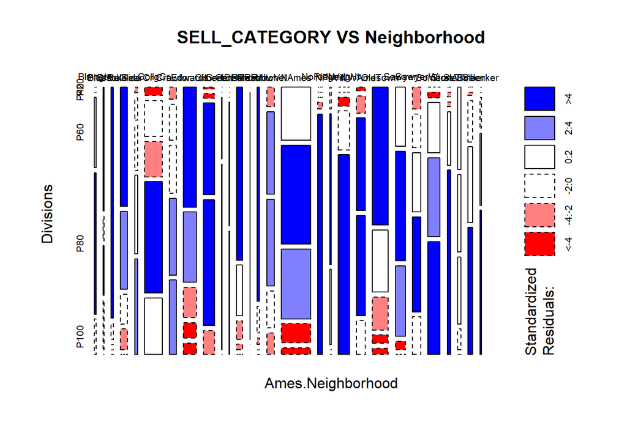

Figure: Mosaic Plot

```r
mosaicplot(~  Ames.Neighborhood + Divisions , data = Categorized_Ames,
           main = "SELL_CATEGORY VS Neighborhood", shade = TRUE) +  theme(axis.text.x.top = element_text(size=6, angle=90))
```

## Boxplot to check Homoscedasticity between Sale Price & Neighborhood.

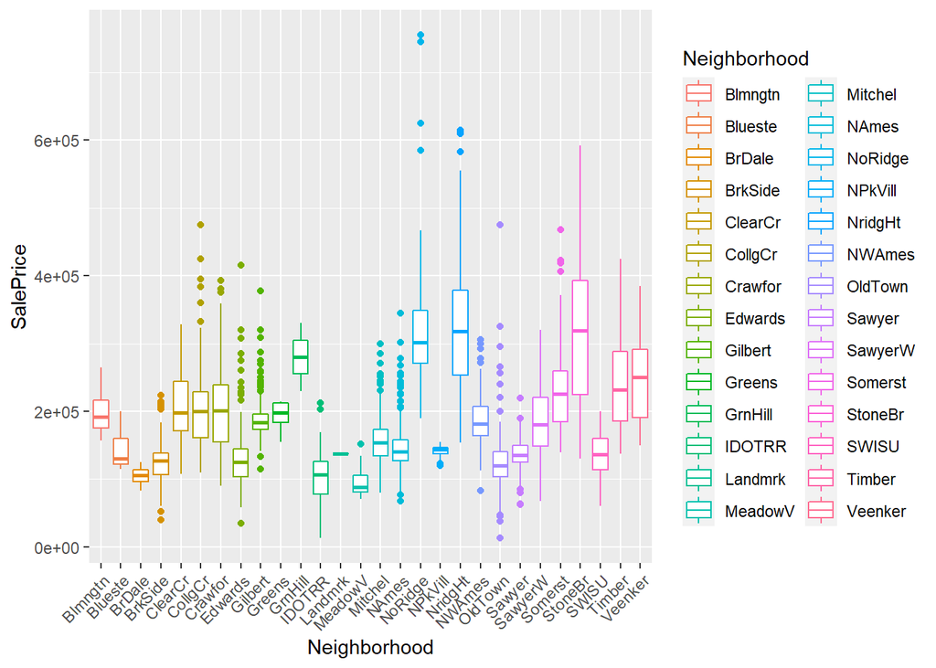

```r
 # Boxplot to understand the relation between Neighborhood and Sale Price

box_plot1 <- ggplot(Dataset_Ames, aes(x = Neighborhood, y =SalePrice, color=Neighborhood)) +

             geom_boxplot()+ theme(axis.text.x = element_text(angle=45, vjust=1, hjust=1))
box_plot1
```

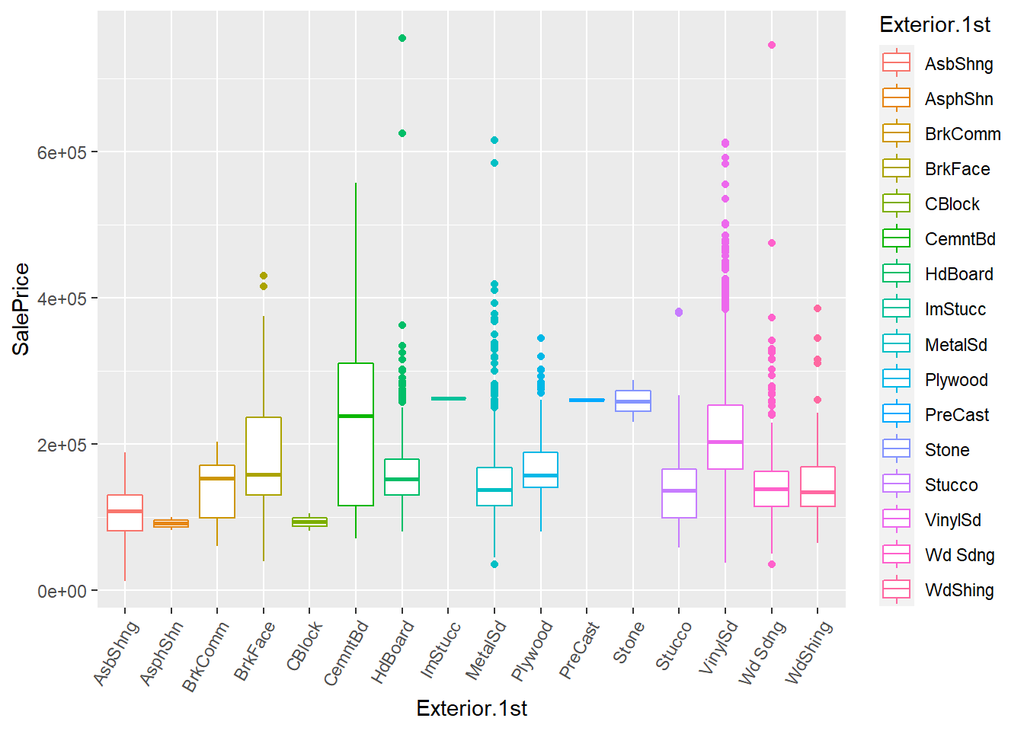

```r
Box_plot2 <- Dataset_Ames %>% ggplot( aes(x = Exterior.1st, y =SalePrice, color=Exterior.1st)) +

             geom_boxplot()+ theme(axis.text.x = element_text(angle=60, vjust=1, hjust=1))


Box_plot2
```

## Contingency Table

- Trying to merge the columns here which contain cell value less than five for the purpose of better result.

```r
Dataset_Ames$Neighborhood[Dataset_Ames$Neighborhood=='Greens']<-'NAmes'  # Trying to merge names column with the greens columns, since the former has less value.

table(factor(Dataset_Ames$Exterior.1st),factor(Dataset_Ames$Neighborhood))
```

```
          Blmngtn Blueste BrDale BrkSide ClearCr CollgCr Crawfor Edwards
  AsbShng       0       0      0       7       0       0       1       7
  AsphShn       0       0      0       0       0       0       0       1
  BrkComm       0       0      0       1       0       0       1       2
  BrkFace       0       0      0       1       2       0      11       4
  CBlock        0       0      0       0       0       0       0       0
  CemntBd       0       0      2       1       0       7      11       3
  HdBoard       0       3     28       4       4      23       5      21
  ImStucc       0       0      0       0       0       0       0       0
  MetalSd       0       7      0      36       3       4      13      37
  Plywood       0       0      0       1      14       4       3      16
  PreCast       0       0      0       0       0       0       0       1
  Stone         0       0      0       0       0       0       1       0
  Stucco        0       0      0       3       0       1       8       6
  VinylSd      26       0      0       9       4     225      10      38
  Wd Sdng       0       0      0      40      15       1      35      45
  WdShing       2       0      0       5       2       2       4      13

          Gilbert GrnHill IDOTRR Landmrk MeadowV Mitchel NAmes NoRidge NPkVill
  AsbShng       1       0      7       0       0       0     5       0       0
  AsphShn       0       0      1       0       0       0     0       0       0
  BrkComm       0       0      0       0       0       0     2       0       0
  BrkFace       1       1      2       0       0       1    41       1       0
  CBlock        0       0      0       0       0       1     0       0       0
  CemntBd       0       0      1       0      37       2     2       0       0
  HdBoard      31       0      3       0       0      38    88      17       0
  ImStucc       0       0      0       0       0       0     0       1       0
  MetalSd       2       0     29       0       0       6   116       5       0
  Plywood       1       0      3       0       0      29    32       0      23
  PreCast       0       0      0       0       0       0     0       0       0
  Stone         0       0      0       0       0       0     0       0       0
  Stucco        0       0      4       0       0       0     3       0       0
  VinylSd     126       0     11       1       0      36    46      42       0
  Wd Sdng       2       1     30       0       0       1   105       5       0
  WdShing       1       0      2       0       0       0    11       0       0

          NridgHt NWAmes OldTown Sawyer SawyerW Somerst StoneBr SWISU Timber
  AsbShng       0      0      16      0       0       0       0     0      0
  AsphShn       0      0       0      0       0       0       0     0      0
  BrkComm       0      0       0      0       0       0       0     0      0
```

[output cut: 16 more lines]

```
  AsphShn       0
  BrkComm       0
  BrkFace       7
  CBlock        0
  CemntBd       0
  HdBoard       2
  ImStucc       0
  MetalSd       2
  Plywood       6
  PreCast       0
  Stone         0
  Stucco        0
  VinylSd       3
  Wd Sdng       2
  WdShing       2
```

## Two-Way Anova Test

Null Hypothesis:

- Ho: There is no difference between the mean of Exteriors.
- Ho: There is no difference between the mean of Neighborhoods.
- Ho: The effect of one independent variable does not depend on the effect of the other independent variable.
- With the two way Anova, we can study the effects of the levels of the individual independent variable on the dependent variable.
- Additionally, we can find out if the independent variables have an interaction amongst themselves.
- The levels in the two independent variables have multiple factors, henceforth we use the two way Anova for our plotting.The dependant variable is generally quantitative in nature. If one of the independent variables is of Quantitative Nature we perform an ANCOVA test.

```r
# Anova test on Neighborhood and Exterior of the building

ames_aov <- aov(SalePrice ~ factor(Exterior.1st)+factor(Neighborhood)+   factor(Neighborhood):factor(Exterior.1st), data = Dataset_Ames)
summary(ames_aov)
```

```
                                            Df    Sum Sq   Mean Sq F value
factor(Exterior.1st)                        15 3.175e+12 2.116e+11  90.690
factor(Neighborhood)                        26 8.019e+12 3.084e+11 132.172
factor(Exterior.1st):factor(Neighborhood)  132 1.067e+12 8.085e+09   3.465
Residuals                                 2756 6.431e+12 2.334e+09
                                          Pr(>F)
factor(Exterior.1st)                      <2e-16 ***
factor(Neighborhood)                      <2e-16 ***
factor(Exterior.1st):factor(Neighborhood) <2e-16 ***
Residuals
---
Signif. codes:  0 '***' 0.001 '**' 0.01 '*' 0.05 '.' 0.1 ' ' 1
```

```r
tukey.ames <- TukeyHSD(ames_aov)
```

- The p value is less than the significance value 0.05, hence forth we fail the null hypothesis.
- A `tukey test` is done to understand if the values at the different levels of the variables are different from one another or not.

## Interaction Plot

- When we want to see if two specific factors have an impact on the dependent variable, we utilize the two-way ANOVA.
- However, there is occasionally a significant interaction between the two factors, which might influence how we understand the relationship between the factors and the response variable.
- An interaction plot is the most straightforward method for detecting and comprehending interaction effects between the two variables.

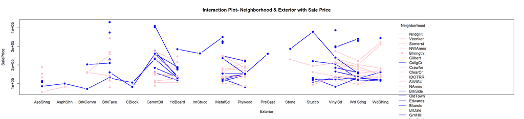

Figure:Interaction Plot

```r
interaction.plot(x.factor = Dataset_Ames$Exterior.1st, #x-axis variable
                 trace.factor = Dataset_Ames$Neighborhood, #variable for lines
                 response = Dataset_Ames$SalePrice, #y-axis variable
                 fun = median, #metric to plot
                 ylab = "SalePrice",
                 xlab = "Exterior",
                 main="Interaction Plot- Neighborhood & Exterior with Sale Price",
                 col = c("pink", "blue"),
                 lty = 1, #line type
                 lwd = 2, #line width
                 pch= c(19),
                 type = 'b',
                 trace.label = "Neighborhood")
```

- We can see from the above plot that there is a lot of interaction between the two variables-Neighborhood and Exterior. This validates why we rejected the Null Hypothesis as well.
- Two way Anova reveals that the p value is less the 0.05 that means we can reject the null hypothesis.

## Analysis & Conclusion

- Chi-square tests can be divided into three categories: goodness of fit, independence, and  
  homogeneity. To generate a test statistic, all three tests use the same methodology.
- Chi-square is most commonly employed by academics who are investigating survey response data since it pertains to categorical variables. Demography, customer engagement research, public  
  administration, and economics are all examples of this type of research.
- When the requirements of equal variances and homoscedascity(`changes in variation of the mean`) are violated and parametric statistics such as the t-test and ANOVA cannot produce reliable findings; we can use the Chi-square to get conclusive analysis results.

## References:-

- pacman Package in R (3 Examples) | p_load, p_unload & p_update. (2021, May 3). Statistics Globe. https://statisticsglobe.com/pacman-r-package
- Changing Numeric Variable to Categorical in R | R Tutorial 5.4 | MarinStatsLectures. (2015, May 25). YouTube. https://www.youtube.com/watch?v=EWs1Ordh8nI
- Density Plot in R with ggplot and geom_density() [R-Graph Gallery Tutorial]. (2021, May 7).  
  YouTube. https://www.youtube.com/watch?v=FzfE8tfbpvQ
- Rhodes, E. (2020, March 31). What does degrees of freedom mean in chi-square? –  
  Runyoncanyon-losangeles.com. Https://Runyoncanyon-Losangeles.Com/.  
  https://runyoncanyon-losangeles.com/blog/what-does-degrees-of-freedom-mean-in-chi-square/
- Pedamkar, P. (2021, June 17). How to Interpret Results Using ANOVA Test? EDUCBA.  
  https://www.educba.com/interpreting-results-using-anova/
- two way anova in r interpretation at DuckDuckGo. (2019, October 12). [Video]. Two Way Anova in r Interpretation. https://duckduckgo.com/?q=two+way+anova+in+r+interpretation&atb=v1-1&iax=videos& ia=videos&iai=https%3A%2F%2Fwww.youtube.com%2Fwatch%3Fv%3D7uR9c_yA0pE
- Smith, Z. M. (2020, March 2). 9 Lesson 4: YAML Headers | R Markdown Crash Course. https://zsmith27.github.io/rmarkdown_crash-course/lesson-4-yaml-headers.html#table-of-contents-toc
- S. (2021, June 18). Mosaic Plot in R. Tutorial Gateway.  
  https://www.tutorialgateway.org/mosaic-plot-in-r/